# Componente ecológico río Piedras

IIB compuesto (macroinvertebrados, peces, perifiton, vegetación) e integración con SWAT

Fecha de publicación

18 de octubre de 2026

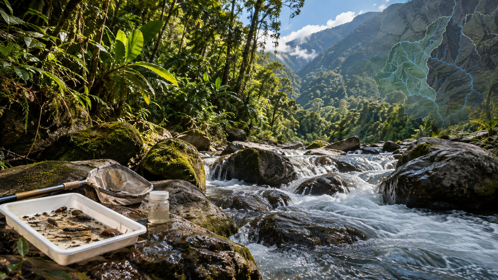

**TipCómo usar esta plantilla**

Los cuatro factores de ponderación (`FP`) del IIBComp (Sección 11) están declarados como **parámetros** en el encabezado YAML (`fp_macroinv`, `fp_peces`, `fp_perif`, `fp_veg`), con 0,25 cada uno por defecto (repartición pareja, siguiendo a Pinilla et al. 2008). En cuanto Fanny confirme si conviene ponderar distinto -por ejemplo, si vegetación de ribera debe pesar menos por tener un único muestreo, o si un componente debe excluirse temporalmente-, basta con cambiar esos cuatro valores (deben sumar 1) y volver a renderizar; ningún otro número del documento hay que tocarlo a mano.

## Resumen ejecutivo: integración del IIB con el modelo SWAT

**Objetivo.** Asociar el estado ecológico medido en campo -ahora con los **cuatro** componentes del IIB (macroinvertebrados, peces, perifiton y vegetación de ribera), combinados en un **IIBComp**- con las variables hidrológicas y de calidad de agua que simula SWAT (caudal, sedimentos, nitrógeno, fósforo) por subcuenca, para entender qué presiones modeladas se asocian mejor con los patrones bióticos observados en cada tramo del río Piedras, y dejar esa asociación calculable de forma reproducible cada vez que haya datos nuevos de uno u otro lado.

**Estrategia de integración** (detalle completo en Sección 12):

1. **Crosswalk tramo↔︎subcuenca**: cada sitio de muestreo biológico se ubica en una subcuenca SWAT específica (Bajo = Los Naranjos = subcuenca 4; Medio = La Lisa = subcuenca 8; Alto = Bocatoma + Finca Atinkana = subcuenca 9).
2. **Alineación temporal**: las salidas de SWAT solo están disponibles para nov-dic 2024. De los cuatro componentes bióticos, macroinvertebrados, peces y perifiton agrupan **ambas campañas** (nov-dic 2024 + may 2025); vegetación de ribera tiene un único muestreo (nov. 2024). Esto significa que tres de los cuatro componentes del IIBComp incorporan información de mayo 2025 sin contraparte en SWAT -ver la nota de Sección 12 sobre lo que eso implica para el cruce.
3. **Agregación de SWAT a esa misma ventana**: caudal promediado (es una tasa), sedimentos y nutrientes sumados (son cargas acumulables mes a mes).
4. **Normalización por área de drenaje**: las tres subcuencas tienen tamaños distintos, así que los totales crudos no son comparables entre sí sin dividir por km².
5. **Cruce (join)** del IIBComp por tramo contra esas variables hidrológicas normalizadas.

**Qué se encontró.** Con el método de puntaje absoluto de Pinilla et al. (2008) (y, para peces y perifiton, el referente propio de cada componente — ver la tabla de la sección siguiente), los cuatro componentes por tramo son:

| Tramo | Macroinv. | Peces | Perifiton | Vegetación | **IIBComp** (FP=0,25 c/u) |
| --- | --- | --- | --- | --- | --- |
| Bajo | 0.76 Alta | 0.93 Alta | 0.53 Moderada | 0.58 Moderada | **0.70 Moderada** |
| Medio | 0.68 Alta | 0.62 Alta | 0.53 Moderada | 0.37 Moderada | **0.55 Moderada** |
| Alto | 0.88 Alta | 0.64 Alta | 0.60 Alta | 0.77 Alta | **0.73 Moderada** |

La clase del IIBComp usa la escala de 4 franjas de la Tabla 30 de Pinilla (2008) -distinta de la escala de 3 franjas de sus componentes-, así que un componente “Alta” (escala de 3 franjas, umbral en 0,6) no se traduce automáticamente en un IIBComp “Alta” (escala de 4 franjas, umbral en 0,8). Para vegetación de ribera, la columna “Moderada/Alta” usa esa misma escala de 3 franjas de Pinilla sobre el valor reescalado 0-1 del RQI/IQR, no las bandas propias de 5 franjas de González del Tánago et al. (2006) (Muy bueno/Bueno/Regular/Pobre/Muy pobre) -ambas lecturas se muestran en Sección 10 porque no son intercambiables y vale la pena que el equipo vea las dos.

Con pesos parejos (0,25 cada uno, el valor por defecto de la propuesta 2008), **los tres tramos quedan en integridad Moderada** para el IIBComp -ninguno cruza el umbral de 0,8 hacia Alta. Bajo y Alto quedan cerca uno del otro (0.70-0.73) y Medio (La Lisa) es el más bajo de los tres (0.55), empujado sobre todo por su vegetación de ribera (0.37, la más baja de los cuatro componentes en ese tramo) y, en menor medida, por tener el perifiton más bajo junto con Bajo -el mismo tramo que, por un margen amplio, exporta más sedimento por km² de drenaje según SWAT (ver más abajo). No se ha vuelto a correr el análisis de sensibilidad a los pesos (Sección 11) con estos números nuevos; queda como pendiente antes de presentar el resultado como robusto.

Esta versión también resuelve varios problemas de calidad de dato y de método que trajo la revisión conjunta con Fanny: el `XLOOKUP` usado para el cruce con `BMWP_COL` en el Excel (no evaluable en LibreOffice) se corrigió a `INDEX/MATCH`; la estandarización relativa (min-max entre los 3 tramos) que se había probado para macroinvertebrados, peces y perifiton se verificó contra la bibliografía citada como respaldo y se revirtió a puntaje absoluto en los tres casos -esa estandarización requiere un pool amplio de sitios de referencia independientes, no los mismos 3 tramos evaluados-; y el proxy de tolerancia de macroinvertebrados pasó del VT genuino de la Tabla 22 (cobertura pobre para géneros neotropicales) a BMWP/Col (Roldán 2003), ya completo para las 102 familias documentadas, unificando así el método que usa el Excel de referencia del proyecto. El detalle completo de cada decisión está en el prompt maestro del proyecto.

**Qué queda pendiente** (detalle completo en Sección 13): validar con Fanny y Carlos si los cuatro `FP` deben seguir en 0,25 parejo o ajustarse (y repetir el análisis de sensibilidad con los números de esta versión); completar la **segunda campaña** (mayo 2025) para Bajo, que sigue sin ella en macroinvertebrados y peces -sesgo documentado en Sección 5 y Sección 8-; evaluar si vale la pena una segunda campaña de vegetación de ribera; y confirmar los 7 puntajes BMWP/Col recién asignados contra la tabla oficial de Roldán (2003).

## Propósito y alcance de este documento

Esta versión extiende el piloto original -que implementaba de principio a fin únicamente **macroinvertebrados**- a los otros tres componentes del IIB (**peces**, **perifiton**, **vegetación de ribera**), siguiendo exactamente el mismo patrón metodológico ya validado: tabulación por tramo → métricas → puntaje absoluto (0,2/0,6/1, o su equivalente continuo cuando no hay tabla de cortes publicada) → IIB por tramo → clasificación semáforo. El resultado se combina en un **IIBComp** ponderado (Sección 11) y se cruza con las salidas de SWAT (Sección 12).

Cada componente usa el referente bibliográfico que efectivamente tiene datos tabulados en `Informe_Fanny_Corregido_oct.18.xlsx`, no necesariamente el mismo de Pinilla (2008) para los cuatro -el porqué de cada sustitución se explica en la sección de cada componente-:

| Componente | Referente usado | Por qué no Pinilla (2008) a secas |
| --- | --- | --- |
| Macroinvertebrados | Pinilla et al. (2008), Tabla 23 | Es el referente original; sin cambios. |
| Peces | Pinto y Araujo (2007) | La Tabla 28 (2008) pide variables que no están en los datos (cambio en % migratorios/amenazados respecto a línea base, Libro Rojo, anormalidades); Fanny ya había seleccionado 7 métricas alternativas d… |
| Perifiton | Rimet y Bouchez (2012) | La Tabla 18 (2008) pide gremios eutróficos/acidobiónticos/alcalifílicos/polisapróbicos que no están clasificados; los datos sí traen gremios de forma de vida (bajo perfil/alto perfil/móvil) de Rimet y… |
| Vegetación de ribera | González del Tánago et al. (2006), RQI/IQR | Pinilla (2008) no trae tabla propia y remite a UNC y MAVDT (2008); el instrumento de campo real fue el RQI/IQR. |

Al final del documento (Sección 13) se detalla qué falta para cerrar del todo el IIBComp (segunda campaña para Bajo, ponderaciones) y para profundizar la integración con SWAT.

## Datos de entrada

Esta versión usa `Informe_Fanny_Corregido_oct.18.xlsx` (el Excel de referencia vigente del proyecto, ver prompt maestro) en vez del `Informe_Fanny.xlsx` original -debe colocarse en `data/raw/` antes de renderizar. Las hojas de datos crudos (`Macroinv.`, `Peces`, `Perifiton`, `Vegetacion`) no cambiaron de estructura entre ambas versiones del archivo, salvo que `Macroinv.` ahora trae una columna adicional `Puntaje BMWP/Col` (col. 14) con el cruce a la hoja `BMWP_COL`, incorporada en la lectura de abajo.

- **Descargar datos crudos para IIB**: `Informe_Fanny_Corregido_oct.18.xlsx` (subir a la misma ruta de GitHub Pages donde estaba `Informe_Fanny.xlsx` -el enlace anterior quedará roto hasta que se suba el archivo con este nombre nuevo)
- **Descargar datos ambientales para SWAT** ([enlace.xlsx](https://javier-2712.github.io/Proyectos/2.proyecto.model.r.piedras/rch.xlsx))

Tabla 1: Registros crudos disponibles por tramo y sitio

| tramo | sitio | n_registros |
| --- | --- | --- |
| Bajo | Los Naranjos | 95 |
| Medio | La Lisa | 172 |
| Alto | Bocatoma | 305 |
| Alto | Finca Atinkana | 50 |

### Dos campañas de muestreo: se agrupan ambas

**Importante**

La hoja `Macroinv.` tiene datos de **dos campañas**: nov-dic 2024 (los 3 tramos) y mayo 2025 (solo Alto y Medio; Bajo no se volvió a muestrear). La versión anterior de este documento usaba solo la campaña 1, por ser la única completa en los tres tramos y por alinearse mejor con la ventana temporal de SWAT (nov-dic 2024).

**Esta versión agrupa ambas campañas**, igualando el criterio que ya se usaba para peces y perifiton (ambos agrupan las dos campañas porque la primera por sí sola deja muestras demasiado pequeñas para calcular riqueza de forma confiable) y replicando la decisión que Fanny tomó en su archivo corregido para macroinvertebrados. Esto introduce un **sesgo reconocido y documentado, no resuelto**: el tramo Bajo queda representado solo por la campaña 1 (nov-dic 2024), mientras Medio y Alto combinan ambas campañas -sus riquezas y abundancias totales no son estrictamente comparables entre sí por este motivo, aunque las métricas de puntaje absoluto (que no dependen de comparar un tramo contra otro) amortiguan parcialmente el problema. Ver también la nota de Sección 12 sobre lo que esto implica para el cruce con SWAT, que solo tiene datos de nov-dic 2024.

Tabla 2: Registros por tramo y campaña — confirmación de que Bajo solo tiene campaña 1

| tramo | campana | n_registros |
| --- | --- | --- |
| Bajo | 1 (nov-dic 2024) | 95 |
| Medio | 1 (nov-dic 2024) | 133 |
| Medio | 2 (may 2025) | 39 |
| Alto | 1 (nov-dic 2024) | 130 |
| Alto | 2 (may 2025) | 225 |

La correspondencia tramo-sitio-subcuenca SWAT usada en todo el documento es la que efectivamente se usó para tabular estos datos (confirmada cruzando las hojas `Macroinv.`, `Peces`, `Perifiton` y `Chl-a`):

| Tramo | Sitio(s) | Subcuenca SWAT |
| --- | --- | --- |
| Bajo | Los Naranjos | 4 |
| Medio | La Lisa | 8 |
| Alto | Bocatoma + Finca Atinkana | 9 |

## Tabulación por tramo

Tabla 3: Cinco familias más abundantes por tramo

| tramo | orden | familia | abundancia |
| --- | --- | --- | --- |
| Bajo | Decapoda | Atyidae | 268 |
| Bajo | Ephemeroptera | Baetidae | 84 |
| Bajo | Ephemeroptera | Leptohyphidae | 46 |
| Bajo | Coleoptera | Elmidae | 28 |
| Bajo | Plecoptera | Perlidae | 26 |
| Medio | Coleoptera | Elmidae | 457 |
| Medio | Diptera | Chironomidae | 237 |
| Medio | Ephemeroptera | Baetidae | 167 |
| Medio | Hemiptera | Naucoridae | 59 |
| Medio | Hemiptera | Veliidae | 47 |
| Alto | Ephemeroptera | Baetidae | 844 |
| Alto | Coleoptera | Elmidae | 372 |
| Alto | Trichoptera | Hydropsychidae | 297 |
| Alto | Diptera | Chironomidae | 277 |
| Alto | Plecoptera | Perlidae | 219 |
| Alto | Trichoptera | Leptoceridae | 219 |

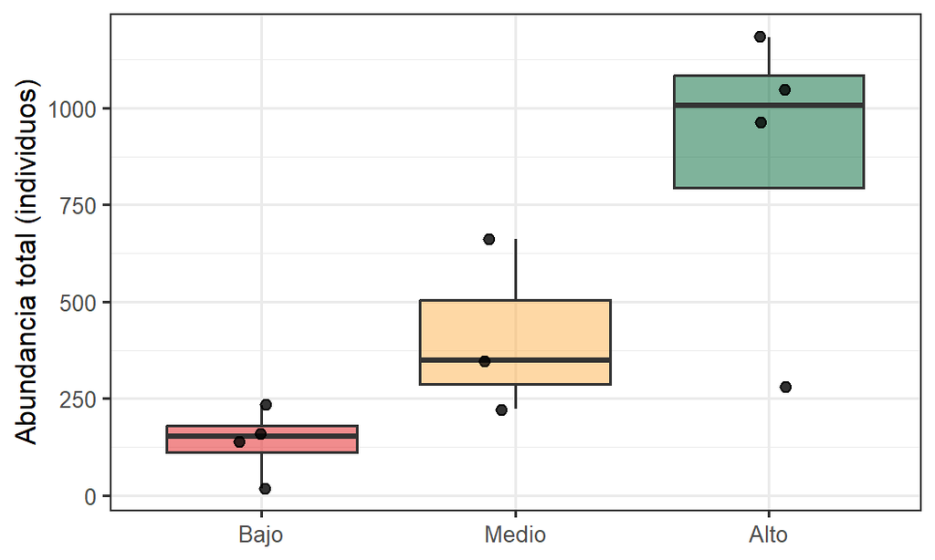

Abundancia total por réplica dentro de cada tramo. Cada punto es una réplica de muestreo, no solo el promedio del tramo.

Hay entre 3 y 5 réplicas por tramo (según microhábitat). Esto importa para más adelante: con datos a nivel de réplica sí es viable correlacionar métricas contra un gradiente de presión (paso 3 de Pinilla), algo que con solo 3 promedios de tramo (n=3) no tiene suficiente potencia estadística. Por ahora las métricas se calculan agregadas por tramo, como en el Excel de Fanny, pero la función queda lista para trabajar a nivel de réplica en cuanto se decida hacer ese análisis con más rigor.

## Métricas por tramo

Tabla 4: Métricas de macroinvertebrados por tramo (Tabla 23, Pinilla et al. 2008)

| Métrica | Bajo | Medio | Alto |
| --- | --- | --- | --- |
| Taxones totales (TT) | 27.0 | 32.0 | 46.0 |
| Taxones Trichoptera (T) | 4.0 | 5.0 | 9.0 |
| Taxones Diptera (D) | 5.0 | 5.0 | 11.0 |
| % Ephemeroptera (E) | 24.5 | 17.5 | 33.9 |
| % EPT | 32.7 | 23.7 | 58.0 |
| % Oligoquetos (O) | 0.0 | 0.0 | 0.2 |
| Taxones intolerantes, BMWP/Col>=7 (I) | 17.0 | 17.0 | 25.0 |
| % Taxones tolerantes, BMWP/Col<=3 (Tol) | 4.7 | 20.4 | 11.1 |
| % Recolectores (R) | 82.9 | 61.3 | 45.0 |
| Taxones filtradores (F) | 1.0 | 2.0 | 2.0 |
| Abundancia total (individuos) | 556.0 | 1234.0 | 3480.0 |
| Cobertura del lookup BMWP/Col (%) | 100.0 | 100.0 | 99.7 |
| BMWP/Col (puntaje de tramo, informativo) | 183.0 | 218.0 | 296.0 |

**AdvertenciaCambio de método: BMWP/Col en vez del VT genuino (Tabla 22) — y por qué**

Las versiones anteriores de este documento calculaban `I`, `Tol` e `IH` con el valor de tolerancia (VT) por género de la Tabla 22 de Pinilla et al. (2008), construida con estudios de Norteamérica, Europa y Australia y con cobertura pobre para géneros neotropicales (en especial *Atya*, dominante en el tramo Bajo, ausente por completo de esa tabla). El Excel de referencia del proyecto (`IIBMA`) nunca usó ese VT: usa **BMWP/Col** (Roldán, 2003) como proxy de tolerancia, a nivel de familia, con “intolerante” = familia con BMWP/Col≥7 y “tolerante” = familia con BMWP/Col≤3 (tercios del rango 1-10 de puntajes BMWP/Col — un supuesto propio, no un corte literal de ninguna fuente).

Esta era la “Inconsistencia abierta entre deliverables” señalada en el prompt maestro del proyecto. Se resuelve aquí adoptando BMWP/Col también en el pipeline R, por dos razones: (1) BMWP/Col ya está completo para las 102 familias documentadas en la hoja `BMWP_COL` de Fanny, mientras que el VT de la Tabla 22 seguía incompleto para géneros neotropicales; y (2) mantiene el Excel y el `.qmd` metodológicamente consistentes (Regla de rigor #5), que es más importante que la fidelidad literal a la Tabla 22 original. El índice de Hilsenhoff (IH) se descarta por completo -no tiene equivalente en las 10 métricas literales de la Tabla 23 que usa el Excel-.

La cobertura real del lookup BMWP/Col sobre la abundancia total es 100% / 100% / 100% (Bajo/Medio/Alto) -mucho mejor que la cobertura del VT que se reemplaza-. El lookup completo (102 familias) está en `data/lookup/bmwp_col.csv`, extraído de la hoja `BMWP_COL` del Excel de referencia. El lookup `data/lookup/vt_macroinvertebrados.csv` queda en el repositorio solo como referencia histórica; ya no se usa en ningún cálculo de esta versión.

## Puntaje absoluto (Tabla 23, Pinilla et al. 2008)

Esto reemplaza la estandarización relativa (min-max entre tramos) de la versión anterior de este documento. En una conversación con Fanny sobre por qué no lograba replicar la estandarización del método, encontramos el informe técnico original (Convenio UNAL–MAVDT 004/2007, 2008) del que sale la propuesta de Pinilla: ahí están las tablas de puntaje completas, y el propio documento aclara que **no se derivaron estadísticamente de datos de campo** — son adaptadas de estudios de otras regiones del mundo, como punto de partida a priori:

> *“Los umbrales propuestos a priori deberán confirmarse o modificarse con base en datos de campo.”* (2008, repetido para cada comunidad)

Por eso no había ninguna estandarización “oculta” que replicar. Con las tablas ya en mano, usarlas directamente es más defendible que la estandarización relativa: cada métrica recibe 0,2 / 0,6 / 1 según en qué franja cae su valor crudo, sin depender de cuántos tramos se muestrearon.

Tabla 5: Puntaje absoluto (0,2 / 0,6 / 1) por métrica y tramo — Tabla 23

| Métrica | Bajo | Medio | Alto |
| --- | --- | --- | --- |
| Taxones totales (TT) | 1.0 | 1.0 | 1.0 |
| Taxones Trichoptera (T) | 0.6 | 0.6 | 1.0 |
| Taxones Diptera (D) | 0.2 | 0.2 | 1.0 |
| % Ephemeroptera (E) | 1.0 | 0.6 | 1.0 |
| % EPT | 0.6 | 0.6 | 1.0 |
| % Oligoquetos (O) | 1.0 | 1.0 | 1.0 |
| Taxones intolerantes, BMWP/Col>=7 (I) | 1.0 | 1.0 | 1.0 |
| % Taxones tolerantes, BMWP/Col<=3 (Tol) | 1.0 | 0.6 | 0.6 |
| % Recolectores (R) | 1.0 | 1.0 | 1.0 |
| Taxones filtradores (F) | 0.2 | 0.2 | 0.2 |

## IIB de macroinvertebrados por tramo

`IIBMacroin = (TT + T + D + %E + %EPT + %O + I + Tol + %CG + Ft) / 10`, las 10 métricas literales de la Tabla 23 de Pinilla et al. (2008), clasificado según la Tabla 24 de la propuesta 2008 (0-0,3 baja · 0,31-0,6 moderada · 0,61-1 alta — la misma escala que usan las Tablas 19 y 29 para perifiton y peces, así que sirve igual para los tres). El índice de Hilsenhoff que llevaban las versiones anteriores de este documento se descartó junto con el VT genuino (ver el callout de la sección anterior).

Tabla 6: IIB de macroinvertebrados por tramo

| Tramo | IIB Macroinvertebrados | Clase |
| --- | --- | --- |
| Bajo | 0.76 | Alta |
| Medio | 0.68 | Alta |
| Alto | 0.88 | Alta |

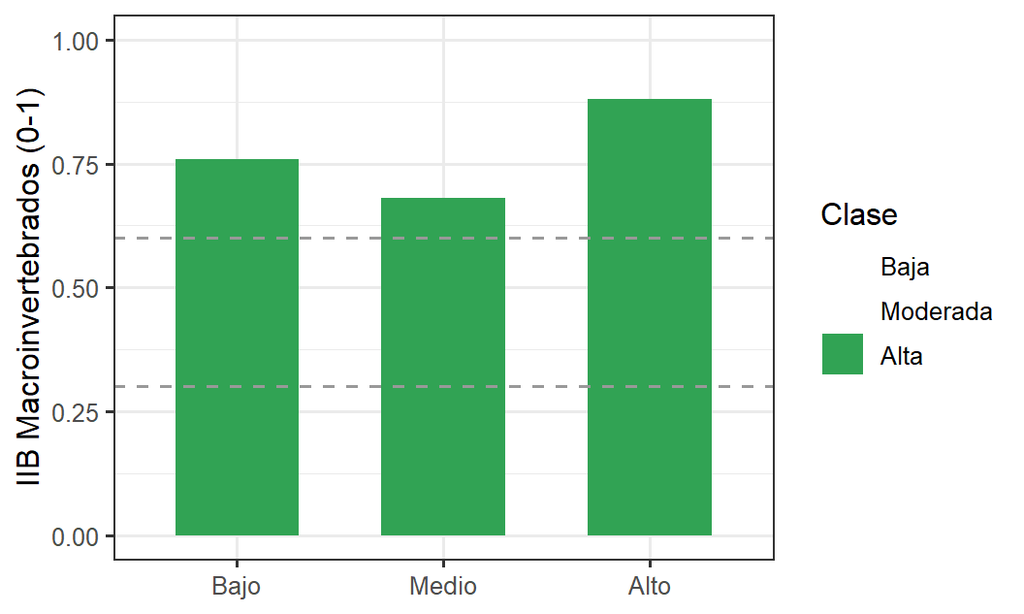

IIB de macroinvertebrados por tramo (Tabla 23-24, Pinilla et al. 2008).

## IIB de peces

Fanny ya había seleccionado, con base en Pinto y Araujo (2007), 7 métricas para peces neotropicales (resaltadas en verde en la hoja `Peces` del Excel): Abundancia, Riqueza, % Herbívoros, % Omnívoros, riqueza de catádromos, % catádromos y riqueza de taxones sensibles. “Pinto y Araujo (2007)”, “Teixeira & Araujo (2007)” (como aparece citado en otra parte del proyecto) y el PDF `Carvalho y Gerson 2007 IIB peces.pdf` son la misma fuente (ver tabla de la sección anterior). Ese autor no publica umbrales numéricos universales (a diferencia de Pinilla 2008, Tabla 28), así que esta versión usa el mismo puntaje absoluto que ya implementó el Excel de referencia, con dos convenciones distintas según el tipo de métrica -ninguna literal de la fuente, ambas marcadas como supuesto propio (Regla de rigor #4)-:

- **Métricas en porcentaje** (%Herb, %Omn, %Cat): los mismos cortes de tercios (33 % / 67 %) que usa la propia Tabla 28 de Pinilla (2008) para sus métricas porcentuales de peces -es una convención transferible, no específica de esa tabla.
- **Métricas de riqueza** (Riqueza, riqueza de catádromos, riqueza de sensibles): se reescalan sobre el total de familias **documentadas** en el muestreo combinado (7 familias en total; 4 catádromas: Eleotridae, Gobiidae, Mugilidae; 3 sensibles: Gobiidae, Mugilidae, Stevardiidae), no sobre el mínimo/máximo de los 3 tramos -así el denominador no cambia si se agrega un tramo o una campaña nueva, por eso sigue siendo “absoluto”-. La versión anterior de este documento usaba en su lugar tercios del máximo observado en el estudio (`max3()`); se reemplaza por este reescalado de pool fijo para igualar el Excel de referencia.

**Abundancia (Ab) se excluye del promedio final**: Carvalho y Gerson (2007) -la misma fuente ya citada- descartaron explícitamente el número total de individuos como métrica del IBI “porque no difirió significativamente entre las muestras, ni presentó correlación con el IBI”. Se deja como dato descriptivo, no puntuable -otro cambio frente a la versión anterior de este documento, que sí la promediaba-.

A diferencia de vegetación de ribera, aquí se agrupan **ambas campañas** (nov-dic 2024 y may 2025): el tramo Alto solo tiene un registro utilizable en la primera campaña, insuficiente para cualquier métrica de riqueza.

Tabla 7: Registros de peces disponibles por tramo (ambas campañas)

| tramo | n_registros |
| --- | --- |
| Bajo | 9 |
| Medio | 6 |
| Alto | 2 |

Tabla 8: Métricas de peces por tramo (Pinto y Araujo 2007 / Romero 2018)

| Métrica | Bajo | Medio | Alto |
| --- | --- | --- | --- |
| Abundancia (Ab) | 221.0 | 209.0 | 35.0 |
| Riqueza (Riq) | 7.0 | 3.0 | 2.0 |
| % individuos Herbívoros (%Herb) | 66.5 | 43.1 | 85.7 |
| % individuos Omnívoros (%Omn) | 30.8 | 56.9 | 14.3 |
| Riqueza de catádromos (Cat) | 4.0 | 2.0 | 1.0 |
| % individuos catádromos (%Cat) | 86.4 | 58.9 | 85.7 |
| Riqueza de taxones sensibles (Sens) | 3.0 | 3.0 | 1.0 |

Tabla 9: Puntaje absoluto de peces por tramo (reescalado sobre pool documentado: 7 familias, 4 catádromas, 3 sensibles)

| Métrica | Bajo | Medio | Alto |
| --- | --- | --- | --- |
| Riqueza (Riq) | 1.0 | 0.429 | 0.286 |
| % individuos Herbívoros (%Herb) | 0.6 | 0.600 | 1.000 |
| % individuos Omnívoros (%Omn) | 1.0 | 0.600 | 1.000 |
| Riqueza de catádromos (Cat) | 1.0 | 0.500 | 0.250 |
| % individuos catádromos (%Cat) | 1.0 | 0.600 | 1.000 |
| Riqueza de taxones sensibles (Sens) | 1.0 | 1.000 | 0.333 |

Tabla 10: IIB de peces por tramo (promedio de las 6 métricas puntuables; Abundancia se excluye)

| Tramo | IIB Peces | Clase |
| --- | --- | --- |
| Bajo | 0.93 | Alta |
| Medio | 0.62 | Alta |
| Alto | 0.64 | Alta |

Los tres tramos quedan en integridad Alta para peces, con Bajo claramente el más alto de los tres (0.93) -tiene los 4 géneros catádromos y los 3 sensibles presentes, el pool completo de riqueza documentada-, y Medio y Alto más cerca entre sí (0.62 y 0.64) por su riqueza más baja (3 y 2 géneros de 7 documentados, respectivamente).

## IIB de perifiton

La hoja `Perifiton` del Excel ya trae, para cada género de diatomea observado, su gremio ecológico según Rimet y Bouchez (2012) (bajo perfil, alto perfil o móvil) y su tolerancia. El índice se construye **solo con los 11 géneros de diatomeas documentados en el estudio** -las cianobacterias y algas verdes quedan como información descriptiva- y se agrupan **ambas campañas** de muestreo (nov-dic 2024 y may 2025) para maximizar el número de géneros observado por tramo. Rimet y Bouchez (2012) es un catálogo taxonómico, no un índice: no trae umbrales numéricos como la Tabla 18 de Pinilla (2008).

La versión anterior de este documento reescalaba, para cada tramo, el **% de los géneros de ese mismo tramo** que caían en cada gremio -una medida de composición relativa, distinta de lo que hace el Excel de referencia. Esta versión replica en cambio el método del Excel: se cuenta, por tramo, cuántos géneros de cada categoría están **presentes** (riqueza, no composición), y ese conteo se divide por el **total de géneros de esa categoría documentados en todo el estudio** (pool fijo: 11 diatomeas en total, 6 sensibles, 3 de bajo perfil, 5 móviles, 3 de alto perfil) -el mismo criterio de “pool documentado, no mínimo/máximo de los 3 tramos” que ya se usa en macroinvertebrados (BMWP/Col) y peces (familias documentadas). El sentido de la tendencia también cambia para dos métricas: Móvil y Alto perfil aumentan con el deterioro, así que su puntaje se invierte (`1 - conteo/total`).

Tabla 11: Registros de perifiton disponibles por tramo (ambas campañas, solo diatomeas)

| tramo | n_registros |
| --- | --- |
| Bajo | 13 |
| Medio | 17 |
| Alto | 26 |

Tabla 12: Riqueza de diatomeas por gremio ecológico y tramo (conteo de géneros presentes, Rimet y Bouchez 2012)

| Métrica | Bajo | Medio | Alto |
| --- | --- | --- | --- |
| Riqueza de diatomeas (Géneros) — pool: 11 | 9 | 7 | 9 |
| Taxones sensibles (Géneros) — pool: 6 | 5 | 3 | 4 |
| Bajo perfil (Géneros) — pool: 3 | 2 | 2 | 3 |
| Móvil (Géneros) — pool: 5 | 5 | 4 | 4 |
| Alto perfil (Géneros) — pool: 3 | 2 | 1 | 2 |

Tabla 13: Puntaje absoluto de perifiton por tramo (conteo de géneros / pool documentado: 11, 6, 3, 5, 3)

| Métrica | Bajo | Medio | Alto |
| --- | --- | --- | --- |
| Riqueza de diatomeas (Géneros) — pool: 11 | 0.818 | 0.636 | 0.818 |
| Taxones sensibles (Géneros) — pool: 6 | 0.833 | 0.500 | 0.667 |
| Bajo perfil (Géneros) — pool: 3 | 0.667 | 0.667 | 1.000 |
| Móvil (Géneros) — pool: 5 | 0.000 | 0.200 | 0.200 |
| Alto perfil (Géneros) — pool: 3 | 0.333 | 0.667 | 0.333 |

Tabla 14: IIB de perifiton por tramo

| Tramo | IIB Perifiton | Clase |
| --- | --- | --- |
| Bajo | 0.53 | Moderada |
| Medio | 0.53 | Moderada |
| Alto | 0.60 | Alta |

## IIB de vegetación de ribera

La hoja `Vegetacion` del Excel ya trae el Índice de Calidad de Riberas (RQI/IQR, González del Tánago et al. 2006) ajustado por tramo (Tabla 1.2 de esa hoja), con **un único muestreo por tramo** (nov. 2024) — no hay una segunda campaña de vegetación de ribera, así que no aplica una comparación por periodo como en los otros tres componentes. El RQI/IQR oscila entre 10 (peor estado) y 120 (mejor estado); se reescala a 0-1 sobre ese rango teórico fijo -no sobre el rango observado en los tres tramos, para mantener el carácter absoluto del puntaje-.

Tabla 15: RQI/IQR ajustado por tramo (Tabla 1.2, hoja Vegetacion)

| Tramo | RQI/IQR total |
| --- | --- |
| Bajo | 73.5 |
| Medio | 51.0 |
| Alto | 95.0 |

Tabla 16: IIB de vegetación de ribera por tramo — dos lecturas de interpretación, ver nota abajo

| Tramo | RQI/IQR | IIBveg (0-1) | Interpretación (RQI, Tabla 1) | Clase (Pinilla, 3 franjas) |
| --- | --- | --- | --- | --- |
| Bajo | 73.5 | 0.577 | Regular | Moderada |
| Medio | 51.0 | 0.373 | Pobre | Moderada |
| Alto | 95.0 | 0.773 | Bueno | Alta |

**Nota**

Esta tabla trae **dos lecturas de interpretación que no son intercambiables**: la columna “Interpretación (RQI)” usa las bandas oficiales de 5 franjas de González del Tánago et al. (2006, Tabla 1: 100-120 Muy bueno, 80-99 Bueno, 60-79 Regular, 40-59 Pobre, 10-39 Muy pobre); la columna “Clase (Pinilla)” usa la escala de 3 franjas (Baja/Moderada/Alta, 0,3/0,6) que sí se usa para los otros tres componentes, aplicada sobre el mismo valor `iib_veg` (0-1). La versión anterior de este documento solo mostraba la lectura RQI, pero el Excel de referencia del proyecto (hoja `IIBVeg`) usa la escala de Pinilla para su columna de interpretación -se muestran ambas aquí en vez de elegir una sola, para que el equipo vea la diferencia (p. ej. Bajo: RQI=“Regular” vs. Pinilla=“Moderada”; Medio: RQI=“Pobre” vs. Pinilla=“Moderada”). Al combinarla en el IIBComp (Sección 11) se usa directamente el valor numérico `iib_veg` (0-1), así que esta elección de etiqueta no afecta el cálculo del compuesto; la clasificación semáforo final del compuesto sigue su propia escala de 4 franjas (Tabla 30).

## IIB compuesto (IIBComp)

`IIBComp = IIBMacroin·FP + IIBPeces·FP + IIBPerif·FP + IIBVegRib·FP`, con los cuatro `FP` declarados como parámetros del documento (ver el aviso al inicio) y clasificado según la Tabla 30 de Pinilla (2008) -una escala de 4 franjas, distinta de la de sus componentes: 0-0,2 pobre · 0,21-0,5 baja · 0,51-0,8 moderada · 0,8-1 alta.

Tabla 17: IIB compuesto por tramo

| Tramo | Macroinv. | Peces | Perifiton | Vegetación | IIBComp | Clase |
| --- | --- | --- | --- | --- | --- | --- |
| Bajo | 0.76 | 0.93 | 0.53 | 0.58 | 0.70 | Moderada |
| Medio | 0.68 | 0.62 | 0.53 | 0.37 | 0.55 | Moderada |
| Alto | 0.88 | 0.64 | 0.60 | 0.77 | 0.73 | Moderada |

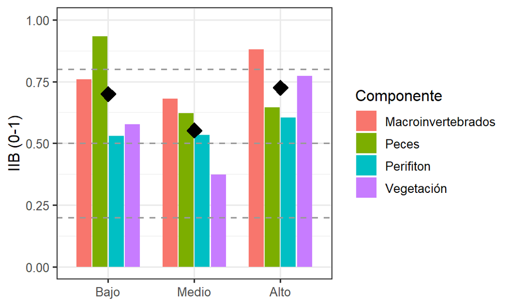

IIB por componente y tramo, con el IIBComp superpuesto (rombo negro).

Con pesos parejos (0,25 cada uno), los tres tramos quedan en integridad **Moderada** para el IIBComp -ninguno alcanza el umbral de 0,8 que exige la Tabla 30 para “Alta”-, con La Lisa (Medio) como el más bajo de los tres en valor numérico (0.55 vs. 0.70-0.73), empujado sobre todo por su vegetación de ribera (0.37, la más baja de los cuatro componentes en ese tramo).

**AdvertenciaQué tan sensible es esto a los pesos – pendiente de repetir con estos números**

La versión anterior de este documento probó reponderar los cuatro componentes en un rango razonable (entre 0,1 y 0,4 cada uno) y encontró que ningún tramo cambiaba de clase. **Ese análisis de sensibilidad no se ha repetido con los números de esta versión** (macroinvertebrados y vegetación de ribera cambiaron de método, y los tres componentes recalculados tienen valores distintos a los anteriores) -no declararlo como “sigue siendo robusto” sin haberlo vuelto a correr sería precisamente el tipo de afirmación no verificada que las reglas de rigor del proyecto piden evitar. Antes de presentar el resultado a Carlos como robusto frente a los pesos, conviene volver a correr esta prueba con los valores de Tabla 17.

## Integración con SWAT

Cruce entre el componente biológico -ahora el **IIBComp** completo- y el modelo hidrológico SWAT. Las salidas de SWAT solo están disponibles para nov-dic 2024, así que ese sigue siendo el ancla temporal de todo el cruce.

**AdvertenciaUn desajuste temporal que hay que tener presente al leer esta sección**

- **Vegetación de ribera**: muestreo único (nov. 2024) — coincide exactamente con SWAT.
- **Macroinvertebrados, peces y perifiton**: los tres agrupan **ambas campañas** (nov-dic 2024 y may. 2025) -decisión descrita en Sección 5, Sección 8 y Sección 9 respectivamente-, porque la primera campaña por sí sola deja muestras demasiado pequeñas para calcular riqueza de forma confiable en varios tramos (peces en Alto queda con un solo género si se usa solo la campaña 1). Esto significa que el IIBComp usado en el cruce de abajo incorpora, para esos tres componentes, información de mayo 2025 que **no tiene contraparte en las variables de SWAT**.

Dentro de esto hay además una asimetría adicional, específica de macroinvertebrados: el tramo **Bajo no tiene campaña 2** (no se volvió a muestrear Los Naranjos en mayo 2025), así que para ese tramo el componente de macroinvertebrados sí queda anclado solo a nov-dic 2024 -coincidiendo con SWAT-, mientras que para Medio y Alto combina ambas campañas. Es decir, el desajuste temporal no es uniforme entre tramos.

La afirmación de que “peces y perifiton no deberían cambiar radicalmente de composición en cinco meses” (usada en versiones anteriores de este documento para justificar la aproximación) **no tiene respaldo bibliográfico verificado para peces** -queda marcada como supuesto propio sin confirmar, no como hecho (ver Sección 13). Para perifiton sí se revisó: el punto no es que la comunidad sea estable en el tiempo, sino que la métrica de gremio ecológico (presencia/ausencia a nivel de género) es relativamente robusta al recambio de especies dentro de un mismo gremio funcional -una distinción distinta a decir que la comunidad no cambia. Vale la pena presentarle esto a Carlos con esa precisión, en vez de dar por sentado que las cuatro fuentes son contemporáneas. Cuando Los Naranjos (Bajo) se muestree en la ventana de mayo 2025 para macroinvertebrados, este cruce podrá rehacerse con **las dos campañas separadas** y comparar si la conclusión cambia.

Tabla 18: Salidas SWAT agregadas por subcuenca, nov-dic 2024 (subcuencas 4, 8 y 9)

| Sub | Área (km²) | Q (cms) | Sed (t) | Sed (t/km²) | N (kg) | N (kg/km²) | P (kg) | P (kg/km²) |
| --- | --- | --- | --- | --- | --- | --- | --- | --- |
| 4 | 15.2 | 0.8 | 15506.0 | 1016.8 | 1904.6 | 124.9 | 410.1 | 26.9 |
| 8 | 13.7 | 0.6 | 69470.0 | 5059.7 | 1425.4 | 103.8 | 346.9 | 25.3 |
| 9 | 33.8 | 1.4 | 722.7 | 21.4 | 3553.0 | 105.2 | 903.9 | 26.8 |

El caudal se promedia entre los dos meses (es una tasa, no un acumulado); sedimentos y nutrientes se suman (son cargas mensuales, sí acumulables). `sedimento_ton_km2`, `n_total_kg_km2` y `p_total_kg_km2` normalizan por área de drenaje, que varía bastante entre las tres subcuencas (Tabla 18) y por eso los totales crudos no son directamente comparables entre tramos. La tabla impresa omite el desglose intermedio (`n_organico_kg`, `p_organico_kg`, `no3_kg`, `nh4_kg`) por espacio — sigue disponible en `swat_agg` y en el CSV exportado más abajo.

El crosswalk tramo-subcuenca es el mismo de la sección de datos de entrada, ahora como objeto de R para poder unirlo:

Tabla 19: Cruce IIBComp (puntaje absoluto) x variables SWAT por tramo (nov-dic 2024, ver advertencia temporal arriba)

| Tramo | Sitio | IIBComp | Clase | Macroinv. | Peces | Perif. | Veg. | Sed (t/km²) | N (kg/km²) | P (kg/km²) |
| --- | --- | --- | --- | --- | --- | --- | --- | --- | --- | --- |
| Bajo | Los Naranjos | 0.70 | Moderada | 0.76 | 0.93 | 0.53 | 0.58 | 1016.79 | 124.89 | 26.89 |
| Medio | La Lisa | 0.55 | Moderada | 0.68 | 0.62 | 0.53 | 0.37 | 5059.72 | 103.82 | 25.26 |
| Alto | Bocatoma/Atinkana | 0.73 | Moderada | 0.88 | 0.64 | 0.60 | 0.77 | 21.40 | 105.21 | 26.77 |

La tabla impresa muestra las columnas más interpretables y evita repetir lo que ya está en Tabla 18 (área, caudal, cargas crudas). El objeto `cruce_iib_swat` y el CSV exportado sí conservan las ~20 columnas completas (`SUB`, cargas crudas de N/P, `no3_kg`, `nh4_kg`, `TT`, `EPT`, `abundancia_total`, etc.) por si se necesitan para un análisis posterior.

Se mantienen también las columnas de cada componente por separado (`iib_macroinv`, `iib_peces`, `iib_perif`, `iib_veg`) junto al `iib_comp`, para poder rastrear -si algún patrón con SWAT resulta interesante- si viene impulsado por un componente en particular o por el compuesto en general.

**ImportanteUn patrón hidrológico que vale la pena discutir con el equipo**

Estas dos observaciones vienen directo de `swat_agg` (Tabla 18) y no dependen del método de puntaje biológico, así que siguen siendo válidas pese al cambio de metodología del IIB y a la incorporación de los tres componentes nuevos:

**Sedimentos**: normalizando por área de drenaje, La Lisa (Medio, sub. 8) exporta muchísimo más sedimento por km² que los otros dos tramos — consistente con lo ya identificado en el informe de resultados SWAT sobre esa subcuenca como fuente crítica, y también es el tramo con el IIBComp numéricamente más bajo de los tres (aunque los tres comparten la clase Moderada; ver Sección 11).

**Nitrógeno y fósforo**: una vez normalizados por área, son prácticamente planos entre los tres tramos. Esto no calza directamente con la narrativa del escenario base 2020 (que señala a las subcuencas bajas como las mayores exportadoras de N/P orgánico) — probablemente porque esa comparación es anual y a nivel de las 10 subcuencas, mientras que este cruce es un corte de solo 2 meses entre 3 subcuencas. Confirmar con Carlos antes de sacar conclusiones.

Revisar en Tabla 19, una vez renderizado con los pesos definitivos, si La Lisa (Medio) sigue siendo el tramo con el IIBComp relativamente más bajo una vez Fanny confirme las ponderaciones -y si eso se sostiene también separando peces y perifiton por campaña (ver advertencia temporal arriba). Con n=3 tramos esto sería una observación, no una correlación con respaldo estadístico.

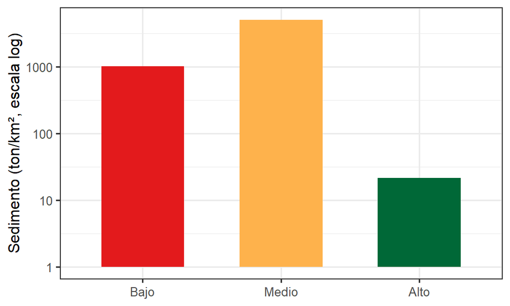

Sedimento exportado por área de drenaje, por tramo (escala log).

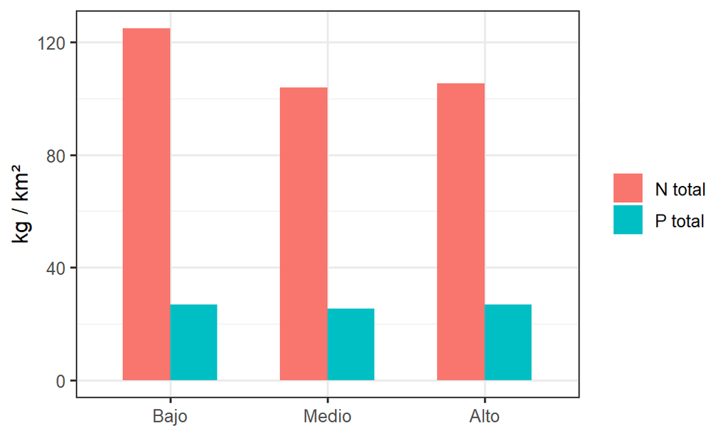

Nitrógeno y fósforo total por área de drenaje, por tramo.

Las dos figuras anteriores muestran cada variable por separado; la siguiente las junta para ver el patrón de una vez: IIBComp contra presión de sedimento, por tramo.

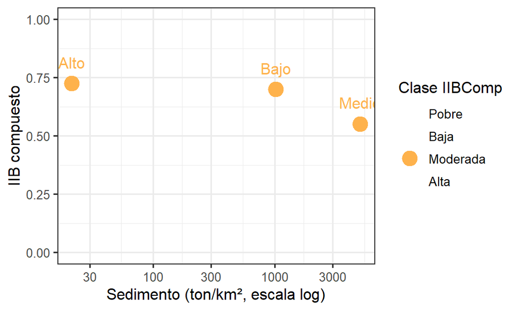

Síntesis: IIBComp vs. sedimento exportado por área de drenaje, por tramo (nov-dic 2024, con la salvedad temporal de peces/perifiton). El eje de sedimento está en escala log por la magnitud de la diferencia entre tramos.

La Lisa (Medio) queda en la esquina menos favorable de los dos ejes a la vez (más sedimento, IIBComp más bajo), y Bocatoma/Atinkana (Alto) y Los Naranjos (Bajo) más cerca de la esquina opuesta. Sigue siendo n=3, así que esto es una observación para ilustrar, no una correlación estadística; vale como punto de partida para la conversación con el equipo, ya con los cuatro componentes en juego.

Este cruce usa `iib_comp`, el compuesto de los cuatro componentes con los pesos declarados en los parámetros del documento (0,25 cada uno por defecto). El patrón de unión (`crosswalk_swat` + `left_join`) es el mismo sin importar cómo se ajusten esos pesos -basta con volver a renderizar tras cambiarlos.

## Próximos pasos

Esta versión sincroniza el `.qmd` con los cambios hechos al Excel de referencia en la sesión del 18 de octubre de 2026 (ver prompt maestro, sección “Resuelto en esta sesión”): agrupa ambas campañas también para macroinvertebrados, reemplaza el VT genuino por BMWP/Col, revierte peces y perifiton de estandarización relativa a puntaje absoluto sobre pools documentados, y actualiza el lookup `bmwp_col.csv` a las 102 familias completas. Varios puntos que estaban pendientes en versiones anteriores de este documento ya se resolvieron (los 7 BMWP/Col sin asignar, la identidad de “Teixeira & Araujo (2007)”, el posible error de doble ponderación del IIBComp). Lo que sigue abierto:

1. **Esta versión del `.qmd` no se ha renderizado todavía con `quarto render` ni con R** -el entorno de esta sesión no tiene R/Quarto instalados ni el archivo de datos crudo en `data/raw/`, así que los números del documento se verificaron replicando la misma lógica en Python directamente contra las fórmulas en vivo del Excel de referencia (coinciden exactamente para los tres componentes reescritos), pero el código R en sí **no se ha ejecutado**. Antes de publicar esta versión en GitHub Pages, alguien con R/Quarto instalado debe renderizarla con `Informe_Fanny_Corregido_oct.18.xlsx` en `data/raw/` y confirmar que no hay errores (Regla de rigor #7) -es el paso más urgente, no el menos importante.
2. **Validar las ponderaciones (`FP`) con Fanny y Carlos**: el documento usa 0,25 parejo por defecto (Sección 11). El análisis de sensibilidad a los pesos que traía la versión anterior no se ha repetido con los números recalculados de esta versión (ver el callout de Sección 11) -hacerlo es parte de renderizar y revisar el punto 1.
3. **Segunda campaña (mayo 2025) para Bajo**: macroinvertebrados y peces todavía tienen a Los Naranjos representado solo por la campaña 1 porque no se ha vuelto a muestrear ese tramo. En cuanto eso pase, se puede calcular el IIBComp por periodo (lluvia vs. sequía) tal como plantea Pinilla et al. (2014).
4. **Verificar el respaldo bibliográfico de la afirmación sobre peces** (“no deberían cambiar radicalmente de composición en 5 meses”, usada para justificar agrupar campañas) -no se encontró una cita que la sostenga; queda marcada como supuesto sin confirmar en Sección 12.
5. **Confirmar los 7 BMWP/Col recién asignados por Fanny** (`Atyidae`=6, `Limoniidae`=4, `Crambidae`=5, `Lumbriculidae`=4, `Perlidae`=10, `Leptoceridae`=8, `Limnesiidae`=5) contra la tabla oficial de Roldán (2003), si hay tiempo antes de dar el BMWP por definitivo.
6. **Vegetación de ribera en los tres tramos, por periodo**: sigue siendo el único componente con un solo dato por tramo sin posibilidad de comparación temporal; conviene decidir con Fanny si vale la pena repetir el RQI/IQR en la ventana de mayo.
7. **Actualizar `README.md` del repositorio** para que refleje el estado real descrito aquí (Regla de rigor #6) -sigue pendiente de esta sincronización.
8. **Robustecer la comparación con SWAT**: sigue siendo n=3 tramos, así que todo lo dicho en Sección 12 son observaciones descriptivas, no correlaciones. Si se llegan a tener más tramos o más ventanas temporales comparables, valdría la pena repetir el cruce con algo más que una inspección visual.